# Apartado 4.7.2 Ejercicio 12

Daniel Ceballos Monsalve

Andrés Felipe Mejía Quintero

Doris Steffania Obando Gonzalez

29/11/2020

## Ejercicio 12

Este problema involucra funciones de escritura.

### Solucion enunciado del punto a

```r
Potencia = function()
{
  2^3
}
print(Potencia())
```

```
## [1] 8
```

### Solucion enunciado del punto b

Cree una nueva función, Potencia2(), que le permita pasar cualquier dos números, x y a, e imprime el valor de (x^a). Puede hacer esto comenzando su función con la línea Potencia2 = function(x, a) {Debería poder llamar a su función ingresando, por ejemplo, Potencia2 (3,8) en la línea de comando. Esto debería generar el valor de 38, es decir, 6, 561.

```r
Potencia2 = function(x, a)
{
  x^a
}
Potencia2(3, 3)
```

```
## [1] 27
```

### Solucion enunciado del punto c

Con la función Potencia2() que acaba de escribir, calcule 10^3, 8^17 y 131^3.

```r
#Calculo de 10^3
Potencia2(10, 3)
```

```
## [1] 1000
```

```r
#Calculo de 8^17
Potencia2(8, 17)
```

```
## [1] 2.2518e+15
```

```r
#Calculo de 131^3
Potencia2(131, 3)
```

```
## [1] 2248091
```

### Solucion enunciado del punto d

Ahora cree una nueva función,Potencia3 (), que realmente devuelva el resultado x ^ a como un objeto R, en lugar de simplemente imprimirlo en la pantalla. Es decir, si almacena el valor (x^a) en un objeto llamado resultado dentro de su función, entonces simplemente puede devolver () este retorno () resultado, usando la siguiente línea: La línea de arriba debe ser la última línea de su función, antes del símbolo}.

```r
Potencia3 = function(x, a) {
    result = x^a
    return(result)
}
```

### Solucion enunciado del punto e

Ahora, usando la función Potencia3 (), cree una gráfica de f (x) = x2. El eje x debe mostrar un rango de números enteros del 1 al 10, y el eje y debe mostrar x2. Rotule los ejes apropiadamente y use un título apropiado para la figura. Considere mostrar el eje x, el eje y o ambos en la escala logarítmica. Puede hacer esto usando log = ‘‘ x’’, log = ‘‘ y’’ o log = ‘‘ xy’’ como argumentos para la función plot ().?

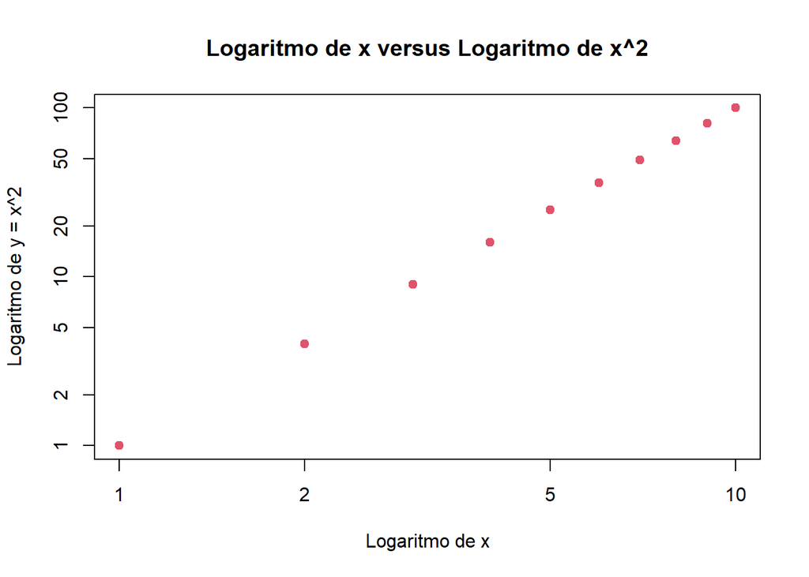

```r
x = 1:10
plot(x, Potencia3(x, 2), log = "xy", ylab = "Logaritmo de y = x^2", xlab = "Logaritmo de x",
    main = "Logaritmo de x versus Logaritmo de x^2",pch=19,col=2)
```

### Solucion enunciado del punto f

Cree una función, PlotPotencia(), que le permita crear una gráfica de x contra x ^ a para una a fija y para un rango de valores de x. Por ejemplo, si llamas PlotPotencia (1:10, 3) entonces se debe crear una gráfica con un eje x tomando valores 1, 2,. . . , 10, y un eje y que toma los valores 1^33, 2^3,. . . , 10^3.

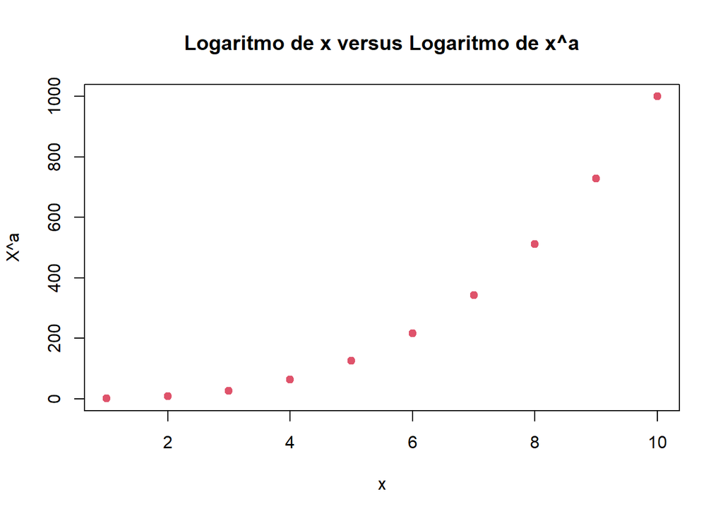

```r
PlotPotencia = function(x, a) {
    plot(x, Potencia3(x, a), ylab = "X^a", main = "Logaritmo de x versus Logaritmo de x^a",pch=19,col=2)
}
PlotPotencia(1:10, 3)
```